# intermediate_R_part_2.Rmd

# Intermediate R Part 2

The goal of this workshop is to build on the fundamentals of data manipulation with the tidyverse we began in Intermediate R Part 1 In that class we learned what tidy data objects (long vs. wide form objects) are, and how to transform data objects using dplyr commands. Today, we will continue to build upon these by introducing how to merge tables, loops, basic statistics, writing functions, and R scripts.

First, we need to set up our working environment. As we did in Intermediate R Part 1, we will set our working directory, load the **tidyverse** package, and source the **prep_data.R** script in order to load datasets for us to work with.

```r
setwd('/Users/ashultz/Dropbox/Workshops/August_2019_Bioinformatics_Shortcourse_Workshops/intro_to_R/')
library(tidyverse)
source("prep_data.R")
```

## Summarzing and aggregating data

Once you have your data organized, you can use the summarize function in dplyr, along with the group_by helper function, to do a lot of powerful stuff.

We’ll continue to explore our mms dataset to demonstrate.

Okay, now what can we do with summarize? First, let’s just get the total number of M&Ms in this dataset:

```r
mms %>% summarize(total_mms=sum(count))
```

```
## # A tibble: 1 x 1
##   total_mms
##       <int>
## 1      1713
```

The group_by function allows us to assign groups, which will then be “unwound” by summarize statements. Easiest to see by example:

```r
mms %>%
  group_by(BagID) %>%
  summarize(mms_per_bag=sum(count)) %>% print %>% summarize(total_mms=sum(mms_per_bag))
```

```
## # A tibble: 30 x 2
##    BagID mms_per_bag
##    <int>       <int>
##  1     1          58
##  2     2          59
##  3     3          59
##  4     4          57
##  5     5          55
##  6     6          58
##  7     7          58
##  8     8          61
##  9     9          58
## 10    10          53
## # … with 20 more rows
```

```
## # A tibble: 1 x 1
##   total_mms
##       <int>
## 1      1713
```

We can also group by totally differetn variables, like color.

```r
mms %>%
  group_by(color) %>%
  summarize(mms_per_color=sum(count)) %>% print %>% summarize(total_mms=sum(mms_per_color))
```

```
## # A tibble: 6 x 2
##   color  mms_per_color
##   <chr>          <int>
## 1 Blue             217
## 2 Brown            374
## 3 Green            222
## 4 Orange           199
## 5 Red              288
## 6 Yellow           413
```

```
## # A tibble: 1 x 1
##   total_mms
##       <int>
## 1      1713
```

Note that summarize outputs a new tibble. You can continue to do calculations on this tibble (for example, if you data has many layers), but you cannot call your original tibble again within the same set of pipes.

We can do some tricky stuff with summarize, group_by, and mutate. For example, let’s get the fraction of each color in each bag:

```r
mms %>%
  group_by(BagID) %>%
  mutate(percent = 100*(count/sum(count))) %>%
  select(-count) %>%
  spread(color, percent)
```

```
## # A tibble: 30 x 8
## # Groups:   BagID [30]
##    Weight BagID  Blue Brown Green Orange   Red Yellow
##     <dbl> <int> <dbl> <dbl> <dbl>  <dbl> <dbl>  <dbl>
##  1   46.2    10  5.66 28.3  17.0   17.0  17.0    15.1
##  2   46.7    26 12.5  33.9  10.7   10.7   7.14   25
##  3   46.9    13 23.6  23.6  16.4    3.64 21.8    10.9
##  4   47.6     5 12.7   7.27  5.45  16.4  18.2    40
##  5   47.7    27 19.3  12.3  21.1   10.5  17.5    19.3
##  6   47.7    28  3.70 29.6   7.41  16.7   9.26   33.3
##  7   48.0    14 14.   14.   14.     4    18      36
##  8   48.3    24  1.79 33.9  10.7   21.4  21.4    10.7
##  9   48.3    16 16.4  36.4  10.9    7.27  7.27   21.8
## 10   48.4     9 17.2  31.0   3.45  10.3   6.90   31.0
## # … with 20 more rows
```

Note there is some subtle stuff going on here. When we us mutant on a grouped tibble, operations like sum() work **within the grouping**. So sum(count) computes the group-wise sum, which means it is easy to get frequencies or percents.

We can then use this insight to explore the data. For example, let’s get the 5 bags of M&Ms with the highest percentage of red candies, conditioning on a weight of at least 47g:

```r
mms %>%
  group_by(BagID) %>%
  mutate(percent = 100*(count/sum(count))) %>%
  select(-count) %>%
  filter(color == "Red", Weight > 47) %>%
  arrange(desc(percent)) %>%
  head(n=5)
```

```
## # A tibble: 5 x 4
## # Groups:   BagID [5]
##   Weight BagID color percent
##    <dbl> <int> <chr>   <dbl>
## 1   50.0    23 Red      35.7
## 2   49.2     4 Red      26.3
## 3   49.8     1 Red      25.9
## 4   49.4    29 Red      25.9
## 5   49.7    18 Red      24.1
```

Note that we can send this to plotting functions like so:

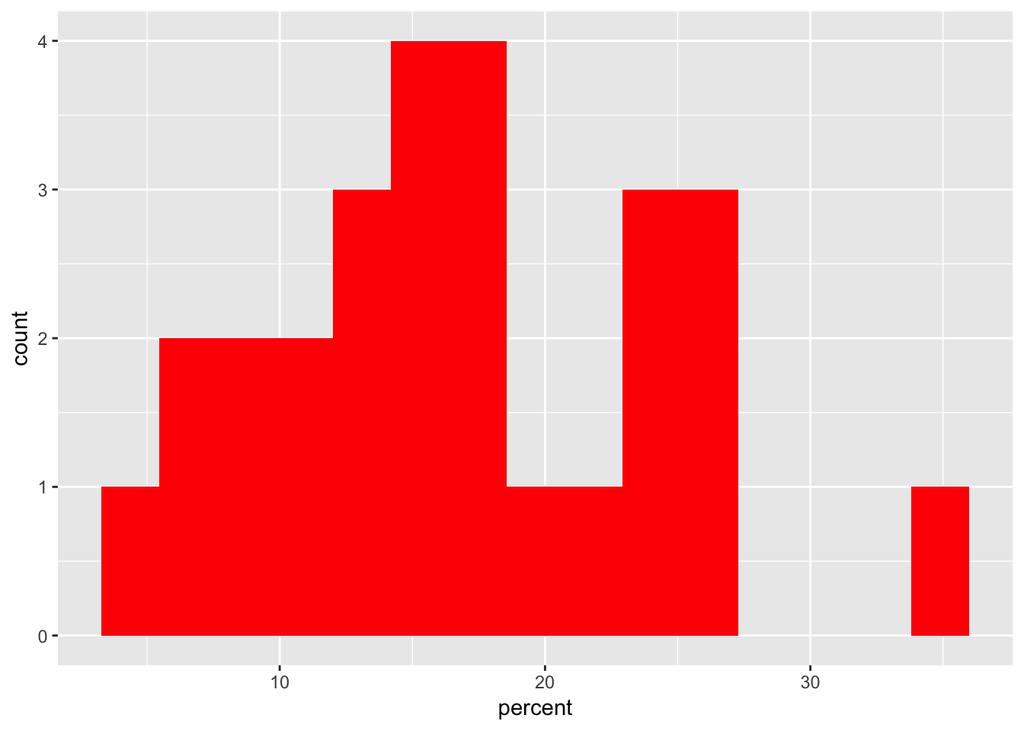

```r
mms %>%
  group_by(BagID) %>%
  mutate(percent = 100*(count/sum(count))) %>%
  select(-count) %>%
  filter(color == "Red", Weight > 47) %>%
  ggplot(aes(percent)) +
  geom_histogram(bins=15,fill="red")
```

For the exercises we will be using the housing_clean dataset, let’s read the csv we created yesterday.

```r
housing_clean <- read_csv("housing_dataset_clean.csv")
#If you need to recreate it:
housing_clean <- housing %>%
  as.tibble %>%
  gather(location, local_index, -Date, -National.US) %>%
  separate(location, c("state", "city"),extra="merge") %>%
  separate(Date, c("year", "month"), extra="drop", remove=F) %>%
  select(year, month, city, state, local_index, national_index=National.US) %>%
  arrange(year, month, state, city) %>%
  mutate(year = as.integer(year), month = month.abb[as.integer(month)], city = sub(".", "_", city, fixed=TRUE), rel_index = local_index/national_index)
```

## Exercises with summarize and group_by

> **Exercise 1:**

> Using the housing_clean dataset, find the three cities with the highest relative index in February, averaged across the years.

> Hint: first filter by month and filter out all values that have missing data with `!is.na()`, then summarize by city using the `mean()` function.

```r
housing_clean %>%
  filter(month=="Feb", !is.na(rel_index)) %>%
  group_by(city) %>%
  summarize(mean_rel_index = mean(rel_index)) %>%
  arrange(desc(mean_rel_index)) %>%
  head(n=3)
```

```
## # A tibble: 3 x 2
##   city        mean_rel_index
##   <chr>                <dbl>
## 1 Washington            1.17
## 2 Los_Angeles           1.15
## 3 Miami                 1.11
```

> **Exercise 2:**

> Now, how has the relative housing index changed through the years, averaged across cities (call year_mean)? Can you produce a line plot of this change?

> Hint: First filter out all missing data. To plot, for the aesthetics, set x = year and y = year_mean, and use geom_line().

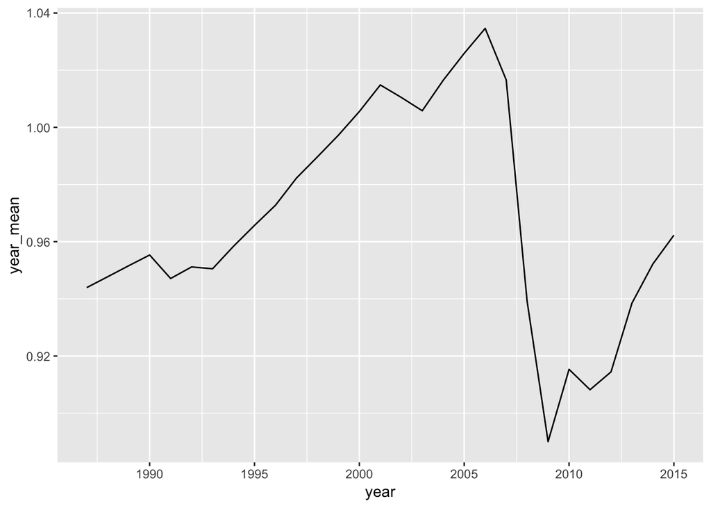

```r
housing_clean %>%
  filter(!is.na(rel_index)) %>%
  group_by(year) %>%
  summarize(year_mean = mean(rel_index)) %>%
  ggplot(aes(x=year,y=year_mean)) +
  geom_line()
```

## Merging data

As a final data processing step, we’ll look at the merge functions in dplyr. These work kind of like sql queries, and take their names from the similar query syntax. All follow the pattern *something*_join. The most common are inner_join, left_join, right_join, and full_join, which keep rows with data in both dataframes, the left dataframe, the right dataframe, or either dataframe, respectively. We’ll look at a couple of examples, and then try a few exercises. Here, we’ll go back to the bird genes under positive selection dataset, and use two additonal datasets to add some additional information.

First, let’s read in the datasets we need. Then, let’s just do a join to add gene names to our dataset, merging on NCBI gene ID (entrezgene).

```r
bird_genes_pvals <- read_csv("data/bird_immune_gene_res_simple.csv")
gg_geneid_names <- read_csv("data/gg_geneid_names.csv")
gg_to_hs_trans <- read_csv("data/gg_to_hs_trans.csv")
bird_genes_pvals
```

```
## # A tibble: 11,247 x 12
##    entrezgene FDRPval_m1m2 FDRPval_m2m2a FDRPval_m7m8 FDRPval_m8m8a
##         <dbl>        <dbl>         <dbl>        <dbl>         <dbl>
##  1         NA        1            1      0.0000000299     0.407
##  2         NA        1            1      0.00000227       0.0553
##  3     422616        1            1      0.0000343        0.236
##  4     422026        1            1      0                0
##  5  100857939        0.154        0.0415 0.0000000427     0.000318
##  6     426168        0            0      0                0
##  7         NA        1            1      0.00201          0.284
##  8     374177        1            1      1                0.796
##  9     427538        0            0      0                0
## 10  100858288        1            1      0.0000103        0.0000422
## # … with 11,237 more rows, and 7 more variables: FDRPval_busted <dbl>,
## #   Prop_m2 <dbl>, Omega_m2 <dbl>, Omega_m0 <dbl>,
## #   prop_sel_branches <dbl>, length <dbl>, nseq <dbl>
```

```r
gg_geneid_names
```

```
## # A tibble: 15,280 x 3
##    entrezgene ensembl_gene_id    external_gene_name
##         <dbl> <chr>              <chr>
##  1     807636 ENSGALG00000042750 ND1
##  2     807645 ENSGALG00000043768 ND2
##  3     807639 ENSGALG00000032142 COX1
##  4     807635 ENSGALG00000032456 COII
##  5     807647 ENSGALG00000032465 <NA>
##  6     807646 ENSGALG00000041091 ATP6
##  7     807637 ENSGALG00000035334 COX3
##  8     807638 ENSGALG00000030436 ND3
##  9     807644 ENSGALG00000042478 ND4L
## 10     807643 ENSGALG00000036229 ND4
## # … with 15,270 more rows
```

```r
gg_to_hs_trans
```

```
## # A tibble: 17,474 x 3
##    entrezgene entrezgene_hs hsapiens_homolog_orthology_confidence
##         <dbl>         <dbl>                                 <dbl>
##  1     807636          4535                                     1
##  2     807645          4536                                     1
##  3     807639          4512                                     1
##  4     807635          4513                                     1
##  5     807647            NA                                    NA
##  6     807646          4508                                     1
##  7     807637          4514                                     1
##  8     807638          4537                                     1
##  9     807644          4539                                     1
## 10     807643          4538                                     1
## # … with 17,464 more rows
```

```r
bird_genes_pvals_trans <- left_join(bird_genes_pvals,gg_geneid_names,by=c("entrezgene"="entrezgene"))
```

Doing a left join means we’ll keep all the rows of data in bird_genes_pvals, even if they don’t have a match in gg_geneid_names, but in theory everything should have a match.

If we wanted to keep everything in gg_geneid_names, even if they were not included in the comparative genomics dataset, we could use a full join, like so:

```r
bird_genes_pvals_trans2 <- bird_genes_pvals %>%
  full_join(.,gg_geneid_names,by="entrezgene") %>%
  select(entrezgene,external_gene_name, FDRPval_busted) %>%
  print
```

```
## # A tibble: 16,637 x 3
##    entrezgene external_gene_name FDRPval_busted
##         <dbl> <chr>                       <dbl>
##  1         NA <NA>                      0.953
##  2         NA <NA>                      0.839
##  3     422616 ADGRL3                    1
##  4     422026 <NA>                      0
##  5  100857939 <NA>                      0.0405
##  6     426168 <NA>                      0
##  7         NA <NA>                      0.00703
##  8     374177 HIF1A                     0.0639
##  9     427538 HYDIN                     0
## 10  100858288 <NA>                      1
## # … with 16,627 more rows
```

Because we did a full join, we’ll get NAs for type for rows where the NCBI gene ID (entrezgene) was not in our comparative genomics table, and NAs for NCBI gene IDs that were not in our gene name translation table.

Inner join just keeps things in both tables. We can use this, for example, to just get the genes that have a gene name, if we first create a filtered tibble.

```r
gg_geneid_names %>%
  filter(!is.na(external_gene_name)) %>%
  inner_join(.,bird_genes_pvals,by="entrezgene") %>% print
```

```
## # A tibble: 8,824 x 14
##    entrezgene ensembl_gene_id external_gene_n… FDRPval_m1m2 FDRPval_m2m2a
##         <dbl> <chr>           <chr>                   <dbl>         <dbl>
##  1     769879 ENSGALG0000004… BAAT                        1             1
##  2     426663 ENSGALG0000003… SPATS2                      1             1
##  3     419140 ENSGALG0000003… EIF6                        1             1
##  4     419907 ENSGALG0000000… LEMD2                       1             1
##  5  100857976 ENSGALG0000004… S1PR2                       1             1
##  6     395937 ENSGALG0000000… TSHB                        1             1
##  7     419909 ENSGALG0000000… C26H6ORF125                 1             1
##  8     404777 ENSGALG0000003… RAD9A                       1             1
##  9     396023 ENSGALG0000000… DKK3                        1             1
## 10     419927 ENSGALG0000000… BYSL                        1             1
## # … with 8,814 more rows, and 9 more variables: FDRPval_m7m8 <dbl>,
## #   FDRPval_m8m8a <dbl>, FDRPval_busted <dbl>, Prop_m2 <dbl>,
## #   Omega_m2 <dbl>, Omega_m0 <dbl>, prop_sel_branches <dbl>, length <dbl>,
## #   nseq <dbl>
```

### Merging Exercise

##Exercise 1 Earlier we loaded an additional dataset called gg_to_hs_trans. This is another translation table, but this time, it translates chicken NCBI gene IDs (entrezgene) to human NCBI gene IDs. Add the human NCBI gene IDs to the bird_genes_pvales dataset. Explore the resulting dataset - what do you notice about the number of rows? What might have caused this?

```r
bird_genes_pvals_hs <- bird_genes_pvals %>%
  left_join(gg_to_hs_trans,by="entrezgene")

#View(bird_genes_pvals_hs)
```

##Exercise 2 An additional column exists with orthology confidence scores (1 = confidence, 0 = not confident). Add the human NCBI gene IDs to the bird_genes_pvales dataset again. However, this time, only include genes where the confidence score is 1. Don’t include the confidence score in the final output. Did this fix the earlier problem?

```r
bird_genes_pvals_hs <- gg_to_hs_trans %>%
  filter(hsapiens_homolog_orthology_confidence==1) %>%
  select(-hsapiens_homolog_orthology_confidence) %>%
  right_join(bird_genes_pvals,by="entrezgene")
```

##Exercise 3 What additional command could you add to fix the issues resulting from the earlier exercises? Also, filter out any rows with missing NCBI gene IDs.

```r
bird_genes_pvals_hs <- gg_to_hs_trans %>%
  filter(hsapiens_homolog_orthology_confidence==1) %>%
  select(-hsapiens_homolog_orthology_confidence) %>%
  right_join(bird_genes_pvals,by="entrezgene") %>%
  distinct(entrezgene,.keep_all=T) %>%
  filter(!is.na(entrezgene))
```

##Exercise 4 How many chicken NCBI gene IDs could be assigned to a human NCBI gene ID?

```r
bird_genes_pvals_hs %>%
  filter(!is.na(entrezgene_hs)) %>%
  summarize(n())
```

```
## # A tibble: 1 x 1
##   `n()`
##   <int>
## 1  9053
```

## Statistics

Now let’s demonstrate a few statistical tests.

With our bird_genes_pvals dataset, we might want to know if there is any difference in the proportion of lineages under selection and whether or not that gene is under selection across all birds. Let’s first make a quick boxplot to look at the data. We are going to add a categorical column with a function called “if_else” (more on that later) as to whether or not a genes is significant.

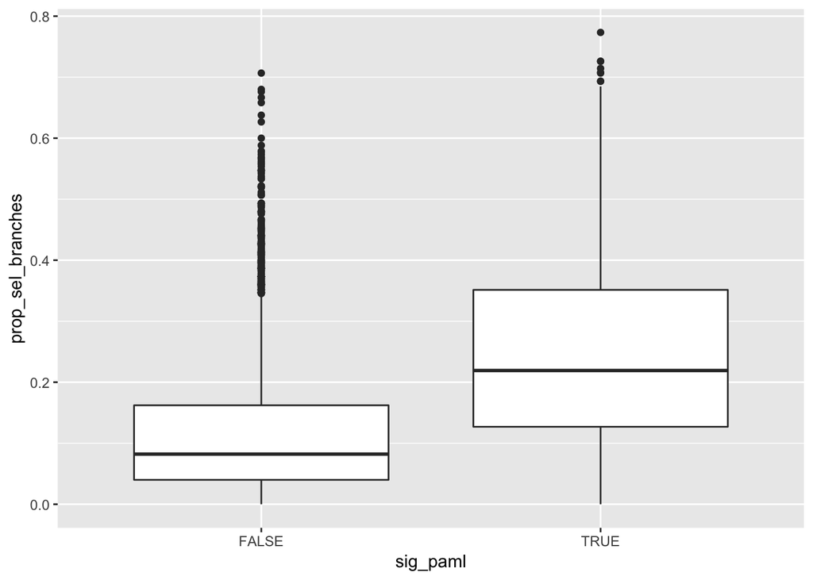

```r
bird_genes_pvals <- bird_genes_pvals %>%
  mutate(sig_paml = if_else(FDRPval_m2m2a<0.05,true=T,false=F))

bird_genes_pvals %>%
  ggplot(aes(x=sig_paml,y=prop_sel_branches)) +
  geom_boxplot()
```

Our boxplot suggests that there are more specific lineages under selection if the gene is signficant across birds. Let’s test that using a T-test.

```r
#note that we can use a logical test as a grouping variable in a formula
bird_genes_pvals %>%
  t.test(data=.,prop_sel_branches ~ sig_paml)
```

```
##
##  Welch Two Sample t-test
##
## data:  prop_sel_branches by sig_paml
## t = -39.276, df = 2666.2, p-value < 2.2e-16
## alternative hypothesis: true difference in means is not equal to 0
## 95 percent confidence interval:
##  -0.1429534 -0.1293582
## sample estimates:
## mean in group FALSE  mean in group TRUE
##           0.1146207           0.2507765
```

We might want to do this non-parameterically using a Wilcoxon Rank Sum Test.

```r
bird_genes_pvals %>%
  wilcox.test(data=.,prop_sel_branches ~ sig_paml)
```

```
##
##  Wilcoxon rank sum test with continuity correction
##
## data:  prop_sel_branches by sig_paml
## W = 4287440, p-value < 2.2e-16
## alternative hypothesis: true location shift is not equal to 0
```

We might hypothesize that gene length is correlated with the likelihood of detecting selection. Let’s test that with cor.test(), and then plot it to see if our hunch might be correct.

```r
cor.test(bird_genes_pvals$length, bird_genes_pvals$Omega_m0)
```

```
##
##  Pearson's product-moment correlation
##
## data:  bird_genes_pvals$length and bird_genes_pvals$Omega_m0
## t = 11.261, df = 11245, p-value < 2.2e-16
## alternative hypothesis: true correlation is not equal to 0
## 95 percent confidence interval:
##  0.08728769 0.12383873
## sample estimates:
##       cor
## 0.1055989
```

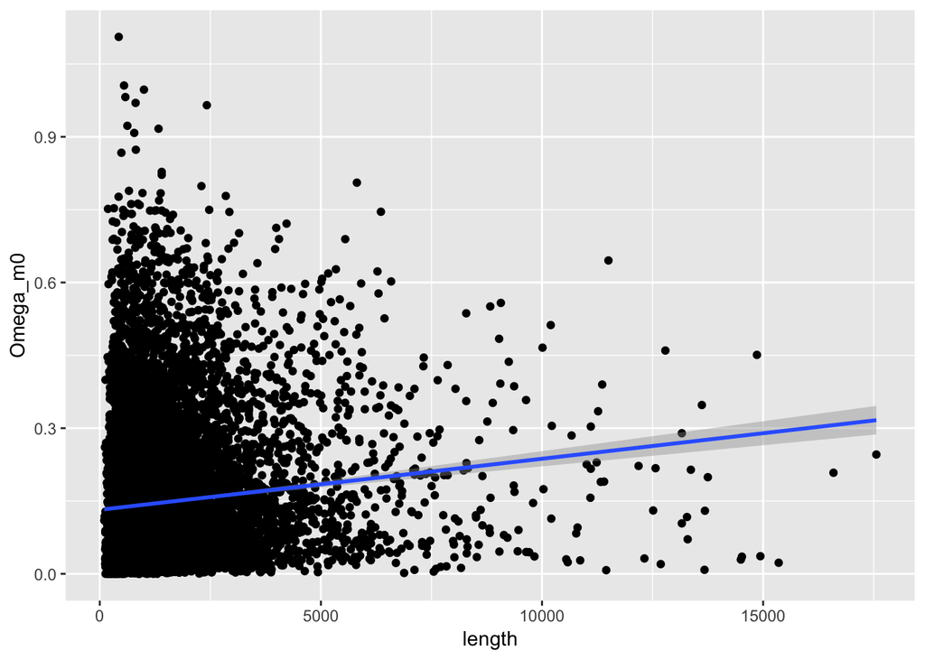

```r
ggplot(bird_genes_pvals,aes(x=length,y=Omega_m0)) +
  geom_point() +
  geom_smooth(method = "lm")
```

Now let’s work through a final example that involves both data manipulation and some more statistical tests. Let’s say we want to find out whether or not there is any difference in how different models are selecting which genes are under of selection. Let’s compare the counts of whether or not a genes is under selection with the Busted model and PAML m2vsm2a model.

First, we need to create a new column in our dataframe, categorizing whether or not a genes is signficant according to Busted.

```r
bird_genes_pvals <- bird_genes_pvals %>%
  mutate(sig_busted = if_else(FDRPval_busted<0.05,true=T,false=F)) %>%
  filter(!is.na(sig_busted))
```

Next, let’s get a sense of how many genes are under selection in the dataset in each case.

Hint: you will need to filter out any missing values.

```r
bird_genes_pvals %>%
  with(.,table(sig_paml,sig_busted))
```

```
##         sig_busted
## sig_paml FALSE TRUE
##    FALSE  4555 4484
##    TRUE    433 1764
```

It seems like there is a difference between the two models in their predictions of which genes are under selection. Let’s test this with a chi-squared test. Let’s pass the table we made earlier to a chi-sq test.

```r
#to test non-independence using an RxC chisquare test, use chisq.test
bird_genes_pvals %>%
  with(.,table(sig_paml,sig_busted)) %>%
  chisq.test
```

```
##
##  Pearson's Chi-squared test with Yates' continuity correction
##
## data:  .
## X-squared = 672.85, df = 1, p-value < 2.2e-16
```

##Statistics Exercises ##Exercise 1 Is there a difference between genes that were significant according to the m2vsm2a PAML model and Omega values (Omega_m2)? Try this both parametrically and non-parametrically

```r
bird_genes_pvals %>%
  t.test(data=.,Omega_m2 ~ sig_paml)
```

```
##
##  Welch Two Sample t-test
##
## data:  Omega_m2 by sig_paml
## t = 38.096, df = 9079.7, p-value < 2.2e-16
## alternative hypothesis: true difference in means is not equal to 0
## 95 percent confidence interval:
##  14.91816 16.53668
## sample estimates:
## mean in group FALSE  mean in group TRUE
##           18.780233            3.052816
```

```r
bird_genes_pvals %>%
  wilcox.test(data=.,prop_sel_branches ~ sig_paml)
```

```
##
##  Wilcoxon rank sum test with continuity correction
##
## data:  prop_sel_branches by sig_paml
## W = 4279596, p-value < 2.2e-16
## alternative hypothesis: true location shift is not equal to 0
```

##Exercise 2 Is there a difference between the proportion of genes under selection between the m1vsm2 and m2vsm2a models?

```r
bird_genes_pvals %>%
  mutate(sig_m1m2=if_else(FDRPval_m1m2<0.05,TRUE,FALSE)) %>%
  with(.,table(sig_paml,sig_m1m2)) %>%
  chisq.test
```

```
##
##  Pearson's Chi-squared test with Yates' continuity correction
##
## data:  .
## X-squared = 9440.4, df = 1, p-value < 2.2e-16
```